# Reproducible Research: Peer Assessment 1

## Loading and preprocessing the data

In order to load the data, we will change the directory and obtain the file from the folder it is stored in.

```r
setwd("~/R/Data")
activity <- read.csv("activity.csv")
```

Using `class(activity[["date"]])`, we find that the date column is stored as characters. We will convert it into Date format to suit our purposes.

```r
activity[["date"]] <- as.Date(activity[["date"]])
```

After loading the data, we will load the required libraries.

```r
library(lattice)
library(dplyr)
```

## What is mean total number of steps taken per day?

We will tackle this topic in ‘steps’. First we take the steps column of the `activity` dataset. We group that dataset by `date` into a dataframe. Then we take the sum of steps for every date and store it in a new vector `dailyTotalSteps`. This process is easily implemented using the pipe operator `%>%`.

```r
dailyTotalSteps <- activity[["steps"]] %>%
  split(as.factor(activity[["date"]])) %>%
  data.frame() %>%
  colSums(na.rm=T)
```

Now we can plot this new vector as a histogram.

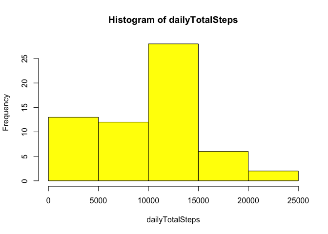

```r
hist(dailyTotalSteps,freq=T,col="yellow")
```

We can also calculate the mean and median of `dailyTotalSteps`

```r
mean(dailyTotalSteps)
```

```
## [1] 9354.23
```

```r
median(dailyTotalSteps)
```

```
## [1] 10395
```

## What is the average daily activity pattern?

Here, we will repeat the process described in the previous part, but instead of grouping by `date`, we will group by `interval`. Since we want the mean steps for every interval, we will use the `colMeans` function instead of `colSums`.

```r
stepsByInterval <- activity[["steps"]] %>%
  split(as.factor(activity[["interval"]])) %>%
  data.frame() %>%
  colMeans(na.rm=T)
```

Now that we have the data for the y-axis, we store the values of unique intervals in a vector for the x-axis.

```r
Intervals <- unique(activity[["interval"]])
```

Now we simply plot the required time series plot.

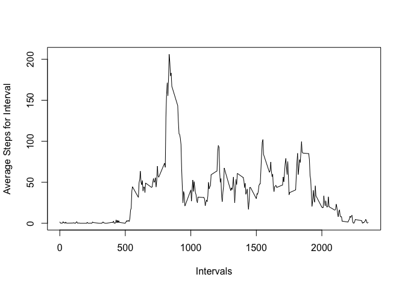

```r
plot(Intervals, stepsByInterval, type = "l", ylab = "Average Steps for Interval")
```

```r
maxAvgSteps <- max(stepsByInterval)
stepsByInterval[stepsByInterval==maxAvgSteps]
```

```
##     X835
## 206.1698
```

## Imputing missing values

First, we calculate the number of `NA` entries in the dataset. We have to only check the `steps` column as it is the only column where values are recorded; the other columns are continuous.

```r
sum(is.na(activity[["steps"]]))
```

```
## [1] 2304
```

Our method of imputation will be to use the mean for the 5-minute interval where the value is missing. We will impute the data using this strategy.

```r
for(i in seq(nrow(activity))) {
  if(is.na(activity[["steps"]][i])) {
    activity[["steps"]][i] <- stepsByInterval[[paste("X",activity[["interval"]][i], sep="")]]
  }
}
```

Now we will recalculate the daily total steps for all days.

```r
dailyTotalSteps <- activity[["steps"]] %>%
  split(as.factor(activity[["date"]])) %>%
  data.frame() %>%
  colSums()
```

We will plot the histogram and calulate the mean and median of the dataset with imputed values to compare it with the original dataset.

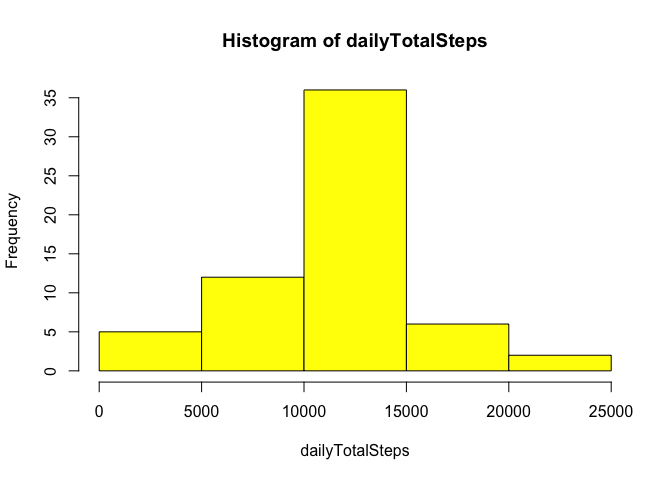

```r
hist(dailyTotalSteps,freq=T,col="yellow")
```

```r
mean(dailyTotalSteps)
```

```
## [1] 10766.19
```

```r
median(dailyTotalSteps)
```

```
## [1] 10766.19
```

The frequency of the higher values in the histogram increases, whereas the frequency of lower values decreases. This is because previously the `NA` values were ignored and had a zero contribution to the total, but in the new dataset, those values contributed to the total steps and shifted the frequency peak rightwards.

## Are there differences in activity patterns between weekdays and weekends?

We start with an empty character vector `weekd`.

```r
weekd<- character(nrow(activity))
```

Then we store weekday/weekend for each row in it.

```r
for(i in seq(nrow(activity))) {
weekd[i]<- if(weekdays(activity[["date"]])[i] %in% c("Sunday","Saturday")) {
  "weekend"
} else {
    "weekday"}
}
```

Finally, we convert it from a character vector to a factor.

```r
weekd <- factor(weekd)
```

Now, we will create a dataframe that will enable us to plot the panel plot. We start with creating stepsByInterval dataframe for weekends only.

```r
weekendSBI <- activity[["steps"]][weekd=="weekend"] %>%
  split(as.factor(activity[["interval"]][weekd=="weekend"])) %>%
  data.frame() %>%
  colMeans(na.rm=T)
```

Then we create one for weekdays only.

```r
weekdaySBI <- activity[["steps"]][weekd=="weekday"] %>%
  split(as.factor(activity[["interval"]][weekd=="weekday"])) %>%
  data.frame() %>%
  colMeans(na.rm=T)
```

Now we create weekend and weekday factors that are separated.

```r
dayFactor <- gl(1,288)
levels(dayFactor) <- c("weekday")
endFactor <- gl(1,288)
levels(endFactor) <- c("weekend")
```

We combine these separately into different dataframes, where x stores weekday data and y stores weekend data.

```r
x<- cbind.data.frame(Intervals, weekdaySBI, dayFactor)
y<- cbind.data.frame(Intervals, weekendSBI, endFactor)
```

We rename the column names for these dataframes.

```r
names(x) <- c("Intervals", "SBI", "weekd")
names(y) <- c("Intervals", "SBI", "weekd")
```

Finally, we merge the dataframes into one dataframe that can be plotted.

```r
mergedSBI <- merge(x,y,by=intersect(names(x), names(y)), all.x=T, all.y=T)
```

Using the `lattice` package, we can plot the required panel plot.

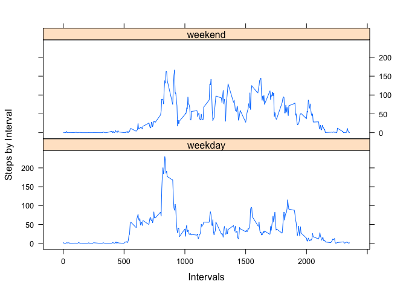

```r
xyplot(mergedSBI$SBI ~ Intervals | weekd, type="l", data=mergedSBI, ylab = "Steps by Interval", layout=c(1,2))
```